# Influenza A Differential Expression Analysis

Author

Alperen Korkmaz

# Differential expression analysis of GSE68849

This analysis uses the public GEO dataset GSE68849 (Illumina HumanHT-12 V4.0, GPL10558): primary human plasmacytoid dendritic cells (pDCs) from donors, exposed to influenza A for 8 hours ex vivo or left as controls (5 vs 5 samples). Differential expression is tested with limma.

## 1. Libraries

```r
library(tidyverse)
library(Biobase)
library(GEOquery)
library(limma)
library(EnhancedVolcano)
library(knitr)
```

## 2. Import the dataset

```r
gse <- getGEO("GSE68849", GSEMatrix = TRUE)
eset <- gse[[1]]
```

The ExpressionSet object holds three parts: `exprs()` (expression values), `pData()` (sample metadata) and `fData()` (probe annotation).

## 3. Sample metadata

```r
p_data <- pData(eset)

p_data |>
  select(any_of(c("geo_accession", "title"))) |>
  kable(caption = "Samples in GSE68849")
```

Samples in GSE68849

|  | geo_accession | title |
| --- | --- | --- |
| GSM1684095 | GSM1684095 | Donor 1 - No virus control - 8h |
| GSM1684096 | GSM1684096 | Donor 1 - Influenza treated - 8h |
| GSM1684097 | GSM1684097 | Donor 2 - No virus control - 8h |
| GSM1684098 | GSM1684098 | Donor 2 - Influenza treated - 8h |
| GSM1684099 | GSM1684099 | Donor 3 - No virus control - 8h |
| GSM1684100 | GSM1684100 | Donor 3 - Influenza treated - 8h |
| GSM1684101 | GSM1684101 | Donor 4 - No virus control - 8h |
| GSM1684102 | GSM1684102 | Donor 4 - Influenza treated - 8h |
| GSM1684103 | GSM1684103 | Donor 5 - No virus control - 8h |
| GSM1684104 | GSM1684104 | Donor 5 - Influenza treated - 8h |

## 4. Expression values

The submitters quantile-normalised the data with Illumina GenomeStudio (as stated in the GEO record). Limma expects log2-scale values, so we check the scale first.

```r
expr <- exprs(eset)
range(expr)
```

```
[1]    67.16471 26775.34000
```

```r
if (max(expr) > 100) {
  if (min(expr) <= 0) {
    stop("Raw-scale values include zero or negative numbers. Check the data before log2.")
  }
  expr <- log2(expr)
}
range(expr)
```

```
[1]  6.069631 14.708617
```

After this step the values should lie roughly between 4 and 16.

## 5. Groups

Group labels are read from the sample titles and characteristics instead of being assumed.

```r
meta_cols <- c("title", grep("characteristics", colnames(p_data), value = TRUE))
meta_text <- apply(p_data[, meta_cols, drop = FALSE], 1, paste, collapse = " ")

group <- factor(
  ifelse(grepl("control", meta_text, ignore.case = TRUE), "control", "flu"),
  levels = c("control", "flu")
)

table(group)
```

```
group
control     flu
      5       5
```

```r
stopifnot(all(table(group) == 5))
```

Check whether the samples are paired by donor (each donor has one control and one flu sample):

```r
donor_match <- regmatches(meta_text,
                          regexpr("donor[ _:-]*[0-9]+", meta_text, ignore.case = TRUE))
paired <- length(donor_match) == length(meta_text)

if (paired) {
  donor <- factor(gsub("\\D", "", donor_match))
  paired <- all(table(donor, group) == 1)
}

paired
```

```
[1] TRUE
```

If `paired` is `TRUE`, the model below includes donor as a blocking factor.

## 6. Collapse probes to genes

Several probes can map to the same gene. For simplicity, probe values of the same gene are averaged.

```r
gene_info <- fData(eset) |>
  select(ID, ILMN_Gene)

expr_genes <- expr |>
  as.data.frame() |>
  rownames_to_column("Prob_ID") |>
  left_join(gene_info, by = c("Prob_ID" = "ID")) |>
  filter(!is.na(ILMN_Gene), ILMN_Gene != "") |>
  select(-Prob_ID) |>
  group_by(ILMN_Gene) |>
  summarize(across(everything(), \(x) mean(x, na.rm = TRUE))) |>
  as.data.frame() |>
  column_to_rownames("ILMN_Gene") |>
  as.matrix()

stopifnot(identical(colnames(expr_genes), rownames(p_data)))
dim(expr_genes)
```

```
[1] 34692    10
```

## 7. Quality control

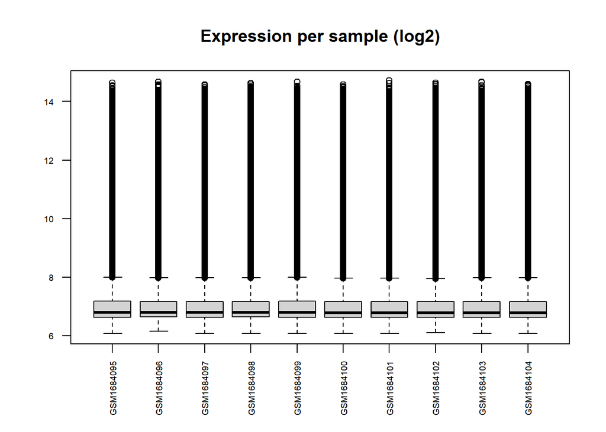

```r
boxplot(expr_genes, las = 2, cex.axis = 0.6,
        main = "Expression per sample (log2)")
```

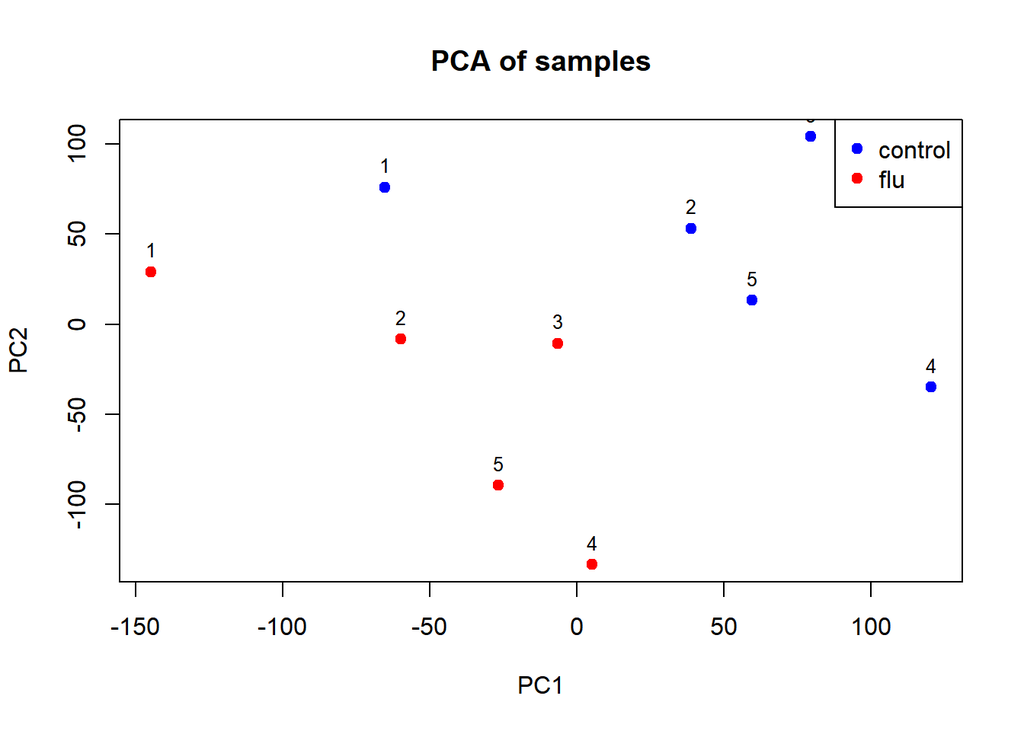

```r
pca <- prcomp(t(expr_genes), scale. = TRUE)
plot(pca$x[, 1], pca$x[, 2],
     col = ifelse(group == "flu", "red", "blue"), pch = 19,
     xlab = "PC1", ylab = "PC2", main = "PCA of samples")
legend("topright", legend = c("control", "flu"),
       col = c("blue", "red"), pch = 19)
text(pca$x[, 1], pca$x[, 2], labels = donor, pos = 3, cex = 0.8)
```

## 8. Differential expression with limma

```r
if (paired) {
  design <- model.matrix(~ donor + group)
} else {
  design <- model.matrix(~ group)
}

fit <- lmFit(expr_genes, design)
fit <- eBayes(fit)

result_table <- topTable(fit, coef = "groupflu", number = Inf,
                         adjust.method = "BH")
result_table$Symbol <- rownames(result_table)
```

## 9. Results

```r
padj_cut <- 0.05
lfc_cut  <- 1

n_sig  <- sum(result_table$adj.P.Val < padj_cut)
n_up   <- sum(result_table$adj.P.Val < padj_cut & result_table$logFC >  lfc_cut)
n_down <- sum(result_table$adj.P.Val < padj_cut & result_table$logFC < -lfc_cut)

top10 <- head(result_table[order(result_table$adj.P.Val),
                           c("Symbol", "logFC", "adj.P.Val")], 10)
```

Using thresholds of adjusted p < 0.05 and |log2 fold change| > 1, 202 genes were upregulated and 137 were downregulated in influenza A-exposed pDCs compared with controls (3413 genes had adjusted p < 0.05 regardless of fold change).

```r
kable(top10, digits = 4, row.names = FALSE,
      caption = "Top 10 genes by adjusted p-value")
```

Top 10 genes by adjusted p-value

| Symbol | logFC | adj.P.Val |
| --- | --- | --- |
| IFNA7 | 7.1881 | 0 |
| IFNA2 | 7.3579 | 0 |
| IFNA21 | 6.9912 | 0 |
| IFNA10 | 7.3941 | 0 |
| IFNA14 | 6.6879 | 0 |
| IFNW1 | 6.2848 | 0 |
| IFNA5 | 6.7699 | 0 |
| IFNA16 | 7.2050 | 0 |
| IFNA4 | 3.4235 | 0 |
| RNF144B | 3.3618 | 0 |

Plasmacytoid dendritic cells are major producers of type I interferons, so a strong interferon-related response after influenza exposure is expected. This agrees with known biology and works as a sanity check, but it does not by itself validate the analysis.

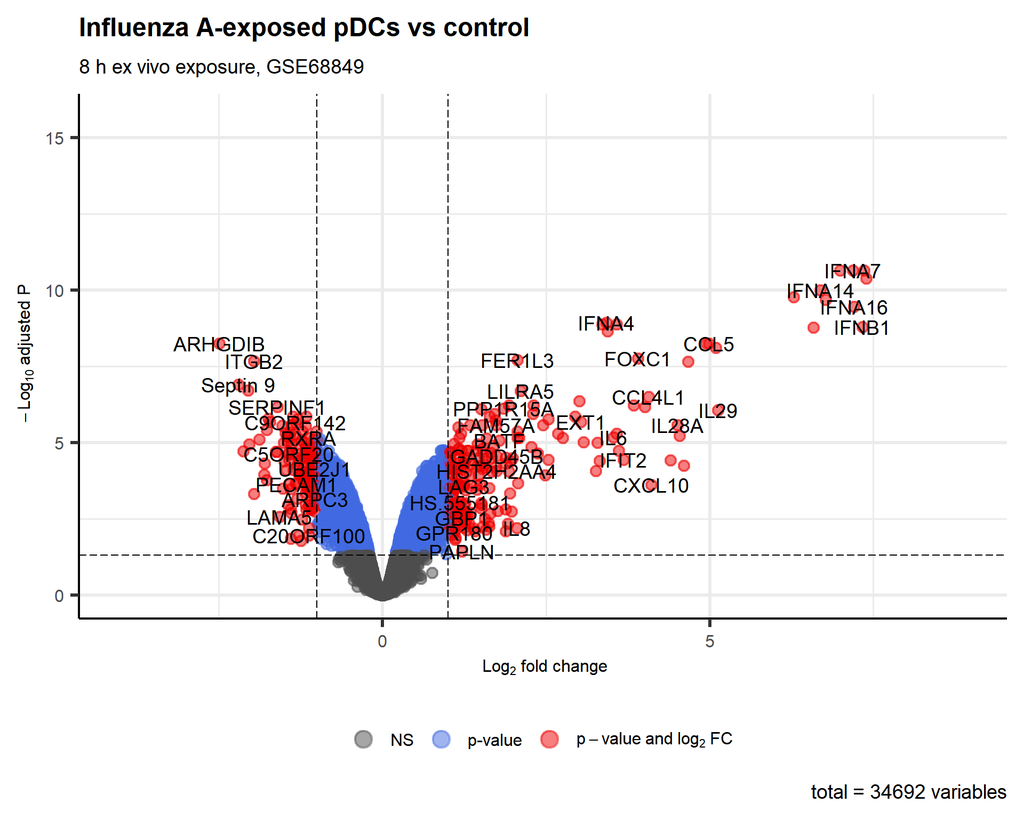

```r
EnhancedVolcano(result_table,
                lab = rownames(result_table),
                x = "logFC",
                y = "adj.P.Val",
                ylab = bquote(~-Log[10]~ "adjusted P"),
                title = "Influenza A-exposed pDCs vs control",
                subtitle = "8 h ex vivo exposure, GSE68849",
                axisLabSize = 12,
                legendLabSize = 12,
                pCutoff = padj_cut,
                FCcutoff = lfc_cut,
                pointSize = 3.0,
                labSize = 5.0,
                legendPosition = "bottom")
```

## 10. Limitations

- Small sample size (5 vs 5).
- Only differential expression was performed; no pathway or GO enrichment yet.
- Probes of the same gene were averaged, which is a simplification.